# Demography Spawn R Package

08/28/2019

## Our Team at CDC

- Molecular Epi and Bioinformatics Team within NCHHSTP (at CDC, of course)
- Laboratory support of investigations of new/emerging retroviruses
- Bioinformatics support to Public Health agencies nationwide
  - Eg. internal cluster to manage/store data MTNAB
- Analytical support to other groups in DHAP
- Suite of tools found [here](https://cdcgov.github.io/MEBT/)

## Organizational Chart

[figure not shown]

NCHHSTP Organizational Chart

## The Problem

- Oftentimes, this group/CDC uses data with personally identifiable information (PII)
- Vetting new tools, but can’t use live data
  - Security restrictions with use of PII
- Not only a CDC/Public Health problem
  - Likely that every market Leidos works in has this issue. Plus could be used internally.

## Potential Solution

- Demography SpawnR aims to solve this – “recreates” a dataset based on distributions of variables in the original
- What is a distribution?
  - Basically, it’s a list/function that gives all possible outcomes and how often they occur
  - Most common is the *normal* distribution, or *the bell curve* (continuous)
  - Can also have frequency distributions

## Example Normal Distribution

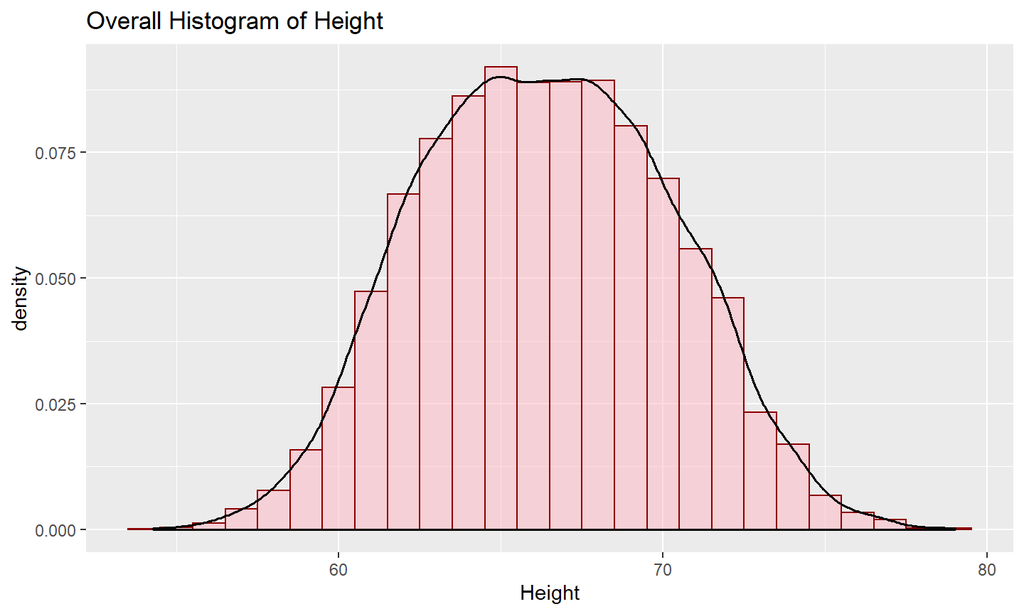

## Example Frequency Distribution

The Great M&M Data

| Color | Frequency | Percentage |
| --- | --- | --- |
| Brown | 17 | 30.9% |
| Red | 18 | 32.7% |
| Blue | 7 | 12.7% |
| Yellow | 6 | 10.9% |
| Green | 4 | 7.3% |
| Orange | 2 | 3.6% |
| Colorless/White | 1 | 1.8% |

## But…

- Overall, heights ~65 inches
- Sometimes, we don’t know the whole story – let’s separate by gender
- There may be underlying patterns in the data we want to tease out
  - We just happen to know in this particular example

## Height by Gender

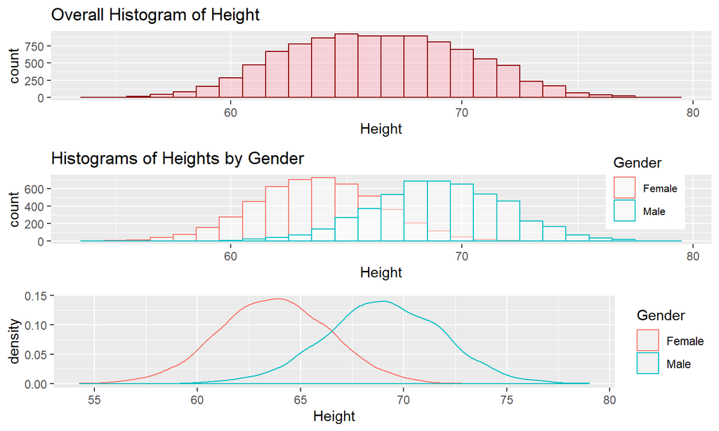

## A pattern arises!

- Notice males generally taller than females
- Want to be able to recreate similar pattern in output dataset
  - More on this later

## Now, what does this package do?

- Goes through variables and attempts to determine each type
  - Continuous, categorical, string, factor, dates, etc.
- A column with all different values is assumed to be sensitive information or PII
  - Name, address, SSN, etc.
    - *Usually*, these aren’t important in analyses, replace with missing values/NA’s.

## How it works

- Computes/determines distributions of each variable
- If categorical, use frequency/percentage of each level
- For continuous variables, populate with random values that follow a normal distribution with respective means/SD
- Dates
  - Generates kernel density estimate
  - Used that as “distribution” and samples – similar to an Epi curve

## Other functionalities

- List all pairwise combinations of variables – continuous/continuous + categorical/categorical
- Correlations/associations and corresponding p-value for above combinations
- If user knows 2 variables to be correlated, able to input those and sample from bivariate distribution

## Potential issues

- Handling with variables that contain zeros
- Categorical variables with several levels (e.g. *> 10* but *< # of rows*)
- In bivariate sampling, variables strongly associated with 2+ others
  - Original: *Var A* associated with *Var B* and *Var C*
  - Sampled: No guarantees *Var A* associated with both after sampling
- Give user choice of which continuous distribution to use – lognormal, gamma, weibull, exponential, etc.
  - Or have package just pick best fitting distribution
- If working with dates – no way to guarantee *date2* comes after *date1* (e.g. patient starting/stopping drug)

## Package Website

[WEBSITE](https://cdcgov.github.io/DemographySpawnR/)

## Acknowledgements

- Tony Boyles
- Ellsworth Campbell
- Bill Switzer
- Sherry Ketemepi
- Stack Overflow

## Comments, Questions, Concerns?

- Thanks!